# test1

## `Estandarización`

${}_mq_n^{\text{C}} = \frac{{}_mD_n^{\text{C}}}{B_n^{\text{C}}}$

**Donde:**

- ${}_{\color{green}m}q_{\color{red}n}^{\color{blue}{\text{C}}}$ es la probabilidad de que un individuo de la $\color{blue}{cohorte\,C}$, muera entre los $\color{red}{n\,años}$ **cumplidos** y antes de los $\color{green}{m}$ años.
- ${}_mD_n^{\text{C}}$ son el número de defunciones de la $\color{blue}{cohorte\,C}$ entre las edades de $\color{red}{n}$ años **cumplidos** y $\color{green}{m}$ años.
- ${}B_n^{\text{C}}$ son las personas expuestas, es decir, el número individuos, que pertenecen a la $\color{blue}{cohorte\,C}$, entre las edades de $\color{red}{n}$ años **cumplidos** y $\color{green}{m}$ años.

## `Diagrama de Lexis-Probabilidades cohorte por edad`

`Ejemplos`

${}_1q_0^{\text{C1980}} = \frac{{}_1D_0^{\text{C1980}}}{B_0^{\text{C1980}}}$

Es la probabilidad de que un $\color{red}{recien\,nacido}$, de la $\color{blue}{cohorte\,de\,1980}$, muera antes de cumplir el $\color{green}{año}$ de edad.

**Donde:**

- ${}_1D_0^{\text{1980}}$ son las defunciones de los infantes nacidos en $\color{blue}{1980}$, $\color{red}{0\,años}$, que no alcanzan el primer $\color{red}{año}$ de edad.
- ${}B_0^{\text{C}}$ son el número de nacimientos en $\color{blue}{1980}$

## `Diagrama de Lexis-Probabilidades cohorte por edad`

`Ejemplos`

${}_1q_0^{\text{C1980}} = \frac{{}_1D_0^{\text{C1980}}}{B_0^{\text{C1980}}}$

${}_5q_{25}^{\text{C1980}} = \frac{{}_5D_{25}^{\text{C1980}}}{B_{25}^{\text{C1980}}}$

Es la probabilidad de que un individuo, perteneciente a la $\color{blue}{cohorte\,de\,1980}$, muera entre los $\color{red}{25\,años}$ cumplidos y los $\color{green}{30\,años}$.

**Donde:**

- ${}_5D_{25}^{\text{C1980}}$ número de defunciones, de la $\color{blue}{cohorte\,de\,1980}$, entre los $\color{red}{25\, años}$ cumplidos y los $\color{green}{30\,años}$.
- ${}B_{25}^{\text{1980}}$ son las personas expuestas: personas de la $\color{blue}{cohorte\,de\,1980}$ y que alcanzan la edad de $\color{red}{25\,años}$

## `Diagrama de Lexis-Probabilidades cohorte por edad`

### `Conteo de los conjuntos` ${}_mD_n^{\text{C}}$ `y` ${}B_n^{\text{C}}$

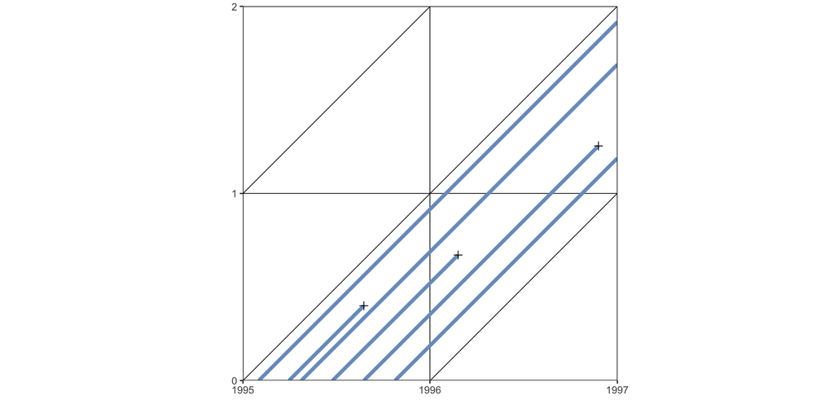

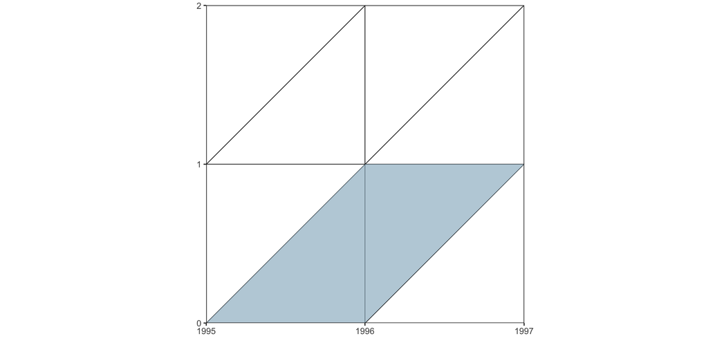

**Haga click sobre las imágenes**

**Nota**

Note que no podriamos calcular ${}_2D_1^{\text{1995}}$, pues el diagrama solo llega hasta **1997**

## `Diagrama de Lexis-Probabilidades cohorte por edad`

### `Conteo de los conjuntos` ${}_mD_n^{\text{C}}$ `y` ${}B_n^{\text{C}}$

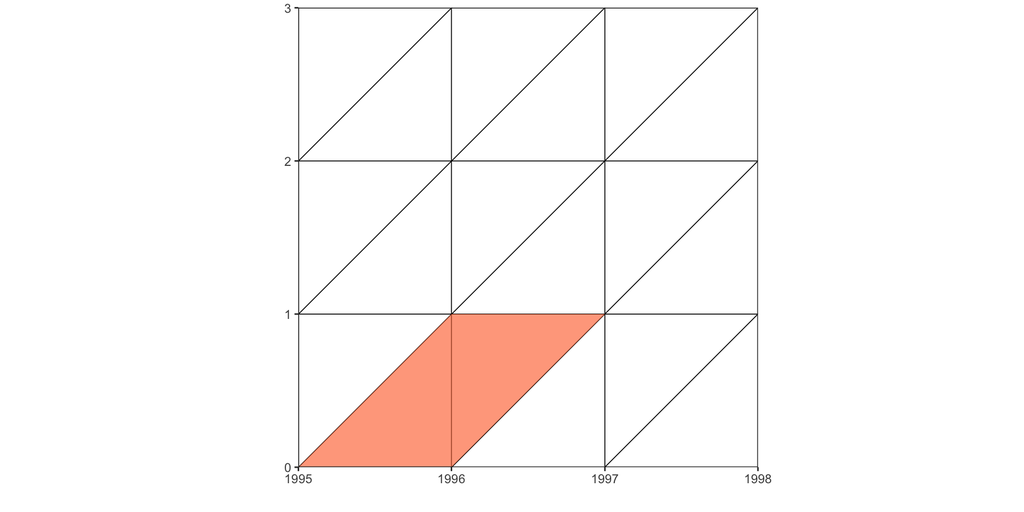

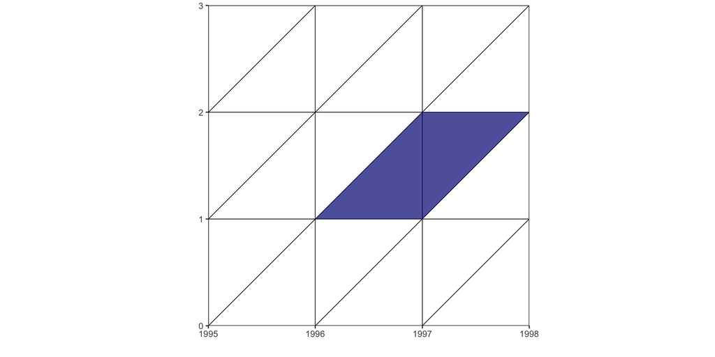

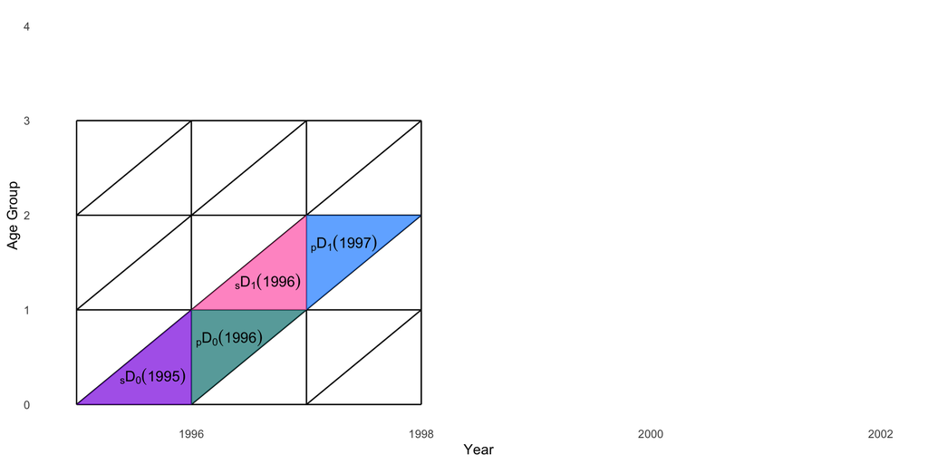

Ahora veamos un ejemplo con ${}_2D^{1995}_0$

Si:

- $\color{#FF7F50}{{}_1D^{1995}_0} = \color{#8A2BE2}{{}_sD(1995)_0} + \color{#008080}{{}_pD(1996)_0}$
- $\color{#000080}{{}_2D^{1995}_1} = \color{#FF69B4}{{}_sD(1996)_1} + \color{#1E90FF}{{}_pD(1997)_1}$

entonces:

## `Diagrama de Lexis-Probabilidades cohorte por edad`

En general tenemos que:

${}_mD^C_n =\displaystyle\sum_{i=1}^{m} {}_1D^{C}_{(n+i-1)}$

**Donde**

- ${}_1D^{C}_{(n+i-1)}$ número de defunciones entre las edades **n+i-1** cumplidas y **n+1**

## `Diagrama de Lexis-Probabilidades cohorte por edad`

En general tenemos que:

${}_mD^C_n =\displaystyle\sum_{i=1}^{m} {}_1D^{C}_{(n+i-1)}$

Además podemos considerar para toda $i=\{1,...,m\}$:

${}_1D^{C}_{(n+i-1)}={}_sD(t+n+i-1)_{(n+i-1)}+{}_pD(t+n+i)_{(n+i-1)}$

con $t=C$

**Donde**

- ${}_sD(t+n+i-1)_{(n+i-1)}$ número de defunciones en el mismo periodo **t+n+i-1**, con **n+i-1** años cumplidos
- ${}_pD(t+n+i)_{(n+i-1)}$ número de defunciones en el periodo inmediato posterior **t+n+i**, con **n+i-1** años cumplidos

## `Diagrama de Lexis-Probabilidades cohorte por edad`

En general tenemos que:

${}_mD^C_n =\displaystyle\sum_{i=1}^{m} {}_1D^{C}_{(n+i-1)}$

Además podemos considerar para toda $i=\{1,...,m\}$:

${}_1D^{C}_{(n+i-1)}={}_sD(t+n+i-1)_{(n+i-1)}+{}_pD(t+n+i)_{(n+i-1)}$

con $t=C$

Por lo que una expresión más general estará dada por:

${}_mD^C_n =\displaystyle\sum_{i=1}^{m} \left[ {}_sD(t+n+i-1)_{(n+i-1)}+{}_pD(t+n+i)_{(n+i-1)}\right]$

## `Diagrama de Lexis-Probabilidades cohorte por edad`

Además podemos considerar para toda $i=\{1,...,m\}$:

${}_1D^{C}_{(n+i-1)}={}_sD(t+n+i-1)_{(n+i-1)}+{}_pD(t+n+i)_{(n+i-1)}$

con $t=C$

Por lo que una expresión más general estará dada por:

${}_mD^C_n =\displaystyle\sum_{i=1}^{m} \left[ {}_sD(t+n+i-1)_{(n+i-1)}+{}_pD(t+n+i)_{(n+i-1)}\right]$

De la expresión anterior podemos deducir que las **las personas expuestas que llegan con n años** es:

$B^{C}_n=B^{C}_o-\displaystyle\sum_{j=1}^{n-1}{}_1D_j^C$

**Donde**

- $B^C_n$ número de personas expuestas con edades de **n** años cumplidos.
- $B^C_0$ número de nacimientos de la cohorte C
- ${}_1D_j^C$ defunciones entre las edades **j** años cumplidos y **j+1**